# Chelicerate coding alignments

```r
knitr::opts_chunk$set(echo = TRUE, warning = FALSE, message = FALSE)

library(ggplot2)
library(cowplot)
library(ggbeeswarm)
library(reshape2)
library(ggpubr)
#library(plyr)
library(dplyr)
library(kableExtra)
library(here)
source("../lib/design.r")
```

# 1 Sequence retrieval

Sequence retrieval and alignment of spider orthogroups was done as follows:

1. Extract CDS and peptide sequences for each orthogroup with sequences from at least 4 species (see https://gwct.github.io/spider-wgd/orthologs.html) while accounting for inconsistencies between CDS and peptide sequences (e.g. sometimes the translation of the CDS sequence doesn’t match because the peptide sequence has extra X’s in it, some CDS have premature stop codons, etc. See below for full accounting).
2. Align CDS sequences with Guidance 2, removing any columns with a score below 0.93 (Guidance default).
3. For each alignment, trim gappy regions by using a sliding window of 3 codons and removing windows that have 2 codons with 2 or more gaps in more than 50% of sequences.
4. After this trimming, for each alignment filter the sequences by removing any that are still made up of >20% gaps.
5. Finally, remove any alignments with sequences from fewer than 4 species or shorter than 33 codons after filtering.
6. Translate to peptide sequence.

# 2 Sequence summary table

```r
get_orths_stats = read.csv(here("data", "get-orths-stats.csv"), header=T)
get_orths_stats = select(get_orths_stats, -Match.code)

get_orths_stats %>% kable() %>% kable_styling(bootstrap_options=c("striped", "condended", "responsive"), full_width=F)
```

| Step | Status.action.taken | X16spec.count | X19spec.count |
| --- | --- | --- | --- |
| Orthogroups with seqs from at least 4 species | Initial | 11983 | 14086 |
| Total sequences from orthogroups with at least 4 species | Initial | 235648 | 296818 |
| CDS sequences with multiple matching headers | Removed | 8 | 10 |
| CDS not divisible by 3 | Attempted to correct (see below) | 4160 | 4200 |
| CDS with premature stop codons | Removed | 652 | 653 |
| CDS with translations that exactly match annotated peptide sequence | Retained | 230002 | 291133 |
| CDS with translations that exactly match annotated peptide sequence AFTER removing X’s from peptide sequence | Corrected and retained | 129 | 131 |
| CDS not divisble by 3, but match peptide sequence after removing 1 or 2 NT from END of the CDS sequence | Corrected and retained | 2926 | 2958 |
| CDS not divisble by 3, but match peptide sequence after removing 1 or 2 NT from BEGINNING of the CDS sequence | Corrected and retained | 728 | 734 |
| CDS whose translation is a subsequence of annotated peptide | Corrected and retained | 129 | 574 |
| CDS whose translation is a subsequence of annotated peptide AFTER removing X’s from peptide sequence | Corrected and retained | 22 | 23 |
| CDS not divisble by 3, but is a subsequence of the annotated peptide sequence after removing 1 or 2 NT from END of the CDS sequence | Corrected and retained | 238 | 241 |
| CDS not divisble by 3, but is a subsequence of the annotated peptide sequence after removing 1 or 2 NT from END of the CDS sequence AND removing X’s from annotated peptide | Corrected and retained | 2 | 2 |
| CDS not divisble by 3, but is a match of the annotated peptide sequence after removing 1 or 2 NT from END of the CDS sequence AND removing X’s from the annotated peptide | Corrected and retained | 1 | 1 |
| CDS sequences with translations that do not match the annotated peptide sequence and cannot easily be corrected | Removed | 1022 | 1011 |
| Total sequences written | Final | 233966 | 295144 |
| Total orthogroups retained | Final | 11936 | 14056 |

## 2.1 Sequences by species

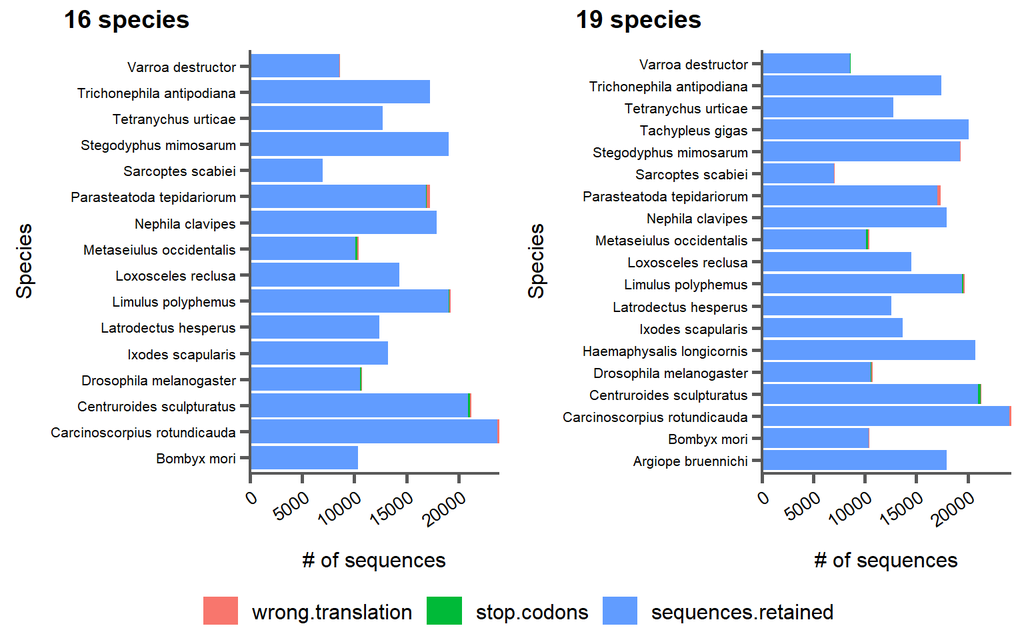

```r
spec_seq_data_orig_16= read.csv(here("data", "16spec", "get-orths-spec-stats.csv"), header=T)
spec_seq_data_16 = select(spec_seq_data_orig_16, -sequences.total, -abbr)
spec_seq_data_long_16 = melt(spec_seq_data_16, id.vars=c("species"))

spec_p_16 = ggplot(spec_seq_data_long_16, aes(x=species, y=value, fill=variable)) +
  geom_bar(position="stack", stat="identity") +
  scale_y_continuous(expand=c(0,0)) +
  xlab("Species") +
  ylab("# of sequences") +
  bartheme() +
  theme(legend.position="bottom",
        axis.text.x=element_text(angle=35, hjust=1),
        axis.text.y=element_text(size=8)) +
  coord_flip()
#print(spec_p_16)

####################

spec_seq_data_orig_19= read.csv(here("data", "19spec", "get-orths-spec-stats.csv"), header=T)
spec_seq_data_19 = select(spec_seq_data_orig_19, -sequences.total, -abbr)
spec_seq_data_long_19 = melt(spec_seq_data_19, id.vars=c("species"))

spec_p_19 = ggplot(spec_seq_data_long_19, aes(x=species, y=value, fill=variable)) +
  geom_bar(position="stack", stat="identity") +
  scale_y_continuous(expand=c(0,0)) +
  xlab("Species") +
  ylab("# of sequences") +
  bartheme() +
  theme(legend.position="bottom",
        axis.text.x=element_text(angle=35, hjust=1),
        axis.text.y=element_text(size=8)) +
  coord_flip()
#print(spec_p_19)

####################

leg = get_legend(spec_p_16)

spec_p_top = plot_grid(spec_p_16 + theme(legend.position="none"), spec_p_19 + theme(legend.position="none"), ncol=2, labels=c("16 species", "19 species"))
spec_p = plot_grid(spec_p_top, leg, nrow=2, rel_heights=c(1,0.1))
print(spec_p)
```

```r
spec_seq_data_orig_16 %>% kable(caption="16 species") %>% kable_styling(bootstrap_options=c("striped", "condended", "responsive"), full_width=F)
```

16 species

| species | abbr | sequences.total | wrong.translation | stop.codons | sequences.retained |
| --- | --- | --- | --- | --- | --- |
| Parasteatoda tepidariorum | ptepi | 17237 | 315 | 24 | 16896 |
| Stegodyphus mimosarum | smimo | 19066 | 18 | 0 | 19048 |
| Trichonephila antipodiana | tanti | 17281 | 1 | 0 | 17280 |
| Carcinoscorpius rotundicauda | crotu | 23880 | 151 | 0 | 23729 |
| Centruroides sculpturatus | cscul | 21224 | 112 | 231 | 20881 |
| Drosophila melanogaster | dmela | 10737 | 83 | 94 | 10560 |
| Ixodes scapularis | iscap | 13238 | 7 | 0 | 13231 |
| Latrodectus hesperus | lhesp | 12397 | 0 | 0 | 12397 |
| Limulus polyphemus | lpoly | 19248 | 114 | 97 | 19031 |
| Loxosceles reclusa | lrecl | 14306 | 0 | 0 | 14306 |
| Metaseiulus occidentalis | mocci | 10400 | 126 | 196 | 10078 |
| Nephila clavipes | nclav | 17927 | 9 | 0 | 17918 |
| Sarcoptes scabiei | sscab | 6989 | 36 | 0 | 6953 |
| Tetranychus urticae | turti | 12748 | 2 | 0 | 12746 |
| Varroa destructor | vdest | 8603 | 17 | 10 | 8576 |
| Bombyx mori | bmori | 10367 | 31 | 0 | 10336 |

```r
spec_seq_data_orig_19 %>% kable(caption="19 species") %>% kable_styling(bootstrap_options=c("striped", "condended", "responsive"), full_width=F)
```

19 species

| species | abbr | sequences.total | wrong.translation | stop.codons | sequences.retained |
| --- | --- | --- | --- | --- | --- |
| Argiope bruennichi | abrue | 17947 | 0 | 0 | 17947 |
| Parasteatoda tepidariorum | ptepi | 17359 | 315 | 24 | 17018 |
| Stegodyphus mimosarum | smimo | 19286 | 18 | 0 | 19268 |
| Trichonephila antipodiana | tanti | 17419 | 1 | 0 | 17418 |
| Carcinoscorpius rotundicauda | crotu | 24218 | 140 | 0 | 24078 |
| Centruroides sculpturatus | cscul | 21356 | 113 | 231 | 21012 |
| Drosophila melanogaster | dmela | 10738 | 83 | 94 | 10561 |
| Haemaphysalis longicornis | hlong | 20736 | 0 | 0 | 20736 |
| Ixodes scapularis | iscap | 13700 | 7 | 0 | 13693 |
| Latrodectus hesperus | lhesp | 12562 | 0 | 0 | 12562 |
| Limulus polyphemus | lpoly | 19692 | 114 | 98 | 19474 |
| Loxosceles reclusa | lrecl | 14526 | 0 | 0 | 14526 |
| Metaseiulus occidentalis | mocci | 10419 | 126 | 196 | 10097 |
| Nephila clavipes | nclav | 17945 | 8 | 0 | 17937 |
| Sarcoptes scabiei | sscab | 7047 | 36 | 0 | 7011 |
| Tachypleus gigas | tgiga | 20076 | 0 | 0 | 20074 |
| Tetranychus urticae | turti | 12763 | 2 | 0 | 12761 |
| Varroa destructor | vdest | 8614 | 17 | 10 | 8587 |
| Bombyx mori | bmori | 10415 | 31 | 0 | 10384 |

# 3 Alignment summary table

```r
aln_data_16 = read.csv(here("data", "16spec", "aln-stats-spec4-seq20-site50.log"), sep="\t", header=T, comment.char="#")
aln_data_16$dataset = "16 species"
aln_data_19 = read.csv(here("data", "19spec", "aln-stats-spec4-seq20-site50.log"), sep="\t", header=T, comment.char="#")
aln_data_19$dataset = "19 species"

aln_data = rbind(aln_data_16, aln_data_19)

aln_summary_data = read.csv(here("data", "aln-stats-summary.csv"), header=T)
aln_summary_data %>% kable() %>% kable_styling(bootstrap_options=c("striped", "condended", "responsive"), full_width=F)
```

| Step | Status.action.taken | Count.16.spec | Count.19.spec |
| --- | --- | --- | --- |
| Alignments before filtering | Initial | 11930 | 14048 |
| Single copy alignments before filtering | Initial | 146 | 288 |
| Sequences before filtering | Initial | 140129 | 178365 |
| Sequences above gappy threshold | Removed | 33869 | 44241 |
| Alignments wither fewer than 4 sequences after filtering | Removed | 2073 | 1736 |
| Alignments shorter than 33 codons after filtering | Removed | 627 | 818 |
| Alignments after filtering | Final | 9638 | 11016 |
| Single copy alignments after filtering | Final | 25 | 218 |
| Sequences after filtering | Final | 98913 | 123558 |

# 4 Alignment length (codons)

Distributions visualized from subset of alignments with length less than 1000 codons.

- Red points denote average lengths considering the FULL distribution
- Blue points denote median lengths considering the FULL distribution
- Table shows summary statistics from FULL distribution

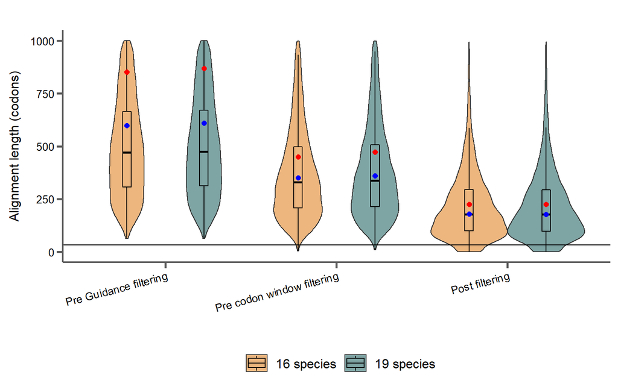

```r
pre_guid_len = select(aln_data, align, pre.guidance.codon.length, dataset)
names(pre_guid_len)[2] = "length"
pre_guid_len$label = "Pre Guidance filtering"

pre_filt_len = select(aln_data, align, pre.codon.aln.length, dataset)
names(pre_filt_len)[2] = "length"
pre_filt_len$label = "Pre codon window filtering"

post_filt_len = select(aln_data, align, post.codon.aln.length, dataset)
names(post_filt_len)[2] = "length"
post_filt_len$label = "Post filtering"

aln_lens = rbind(pre_guid_len, pre_filt_len, post_filt_len)

aln_means = aln_lens %>% group_by(dataset, label) %>% summarize(avg.length=mean(length, na.rm=T), median.length=median(length, na.rm=T), max.length=max(length, na.rm=T))

aln_lens$label = factor(aln_lens$label, levels=c("Pre Guidance filtering", "Pre codon window filtering", "Post filtering"), ordered=T)
aln_lens$dataset = factor(aln_lens$dataset, levels=c("16 species", "19 species"), ordered=T)
aln_lens = subset(aln_lens, length < 1000)

aln_means$label = factor(aln_means$label, levels=c("Pre Guidance filtering", "Pre codon window filtering", "Post filtering"), ordered=T)

dodge = position_dodge(width = 0.9)

aln_lens_p = ggplot(aln_lens, aes(x=label, y=length, fill=dataset)) +
  #geom_quasirandom(aes(color=dataset), size=2, width=0.25, alpha=0.1, color="#666666") +
  geom_violin(alpha=0.5, position=dodge) +
  geom_boxplot(outlier.shape=NA, alpha=0, width=0.1, position=dodge, color="#000000") +
  geom_point(data=aln_means, aes(x=label, y=avg.length, group=dataset), size=2, color="red", position=dodge, show.legend=FALSE) +
  geom_point(data=aln_means, aes(x=label, y=median.length, group=dataset), size=2, color="blue", position=dodge, show.legend=FALSE) +
  geom_hline(yintercept=33) +
  ylab("Alignment length (codons)") +
  xlab("") +
  scale_fill_manual(labels=c("16 species", "19 species"), values=corecol()) +
  bartheme() +
  theme(legend.position="bottom", axis.text.x = element_text(angle=15, hjust=1))
print(aln_lens_p)
```

```r
aln_means %>% kable() %>% kable_styling(bootstrap_options=c("striped", "condended", "responsive"), full_width=F)
```

| dataset | label | avg.length | median.length | max.length |
| --- | --- | --- | --- | --- |
| 16 species | Post filtering | 225.1880 | 180.0000 | 3043.00 |
| 16 species | Pre codon window filtering | 450.6338 | 350.0000 | 4321.00 |
| 16 species | Pre Guidance filtering | 851.4450 | 598.6667 | 11386.67 |
| 19 species | Post filtering | 224.3748 | 178.0000 | 3078.00 |
| 19 species | Pre codon window filtering | 472.3178 | 361.0000 | 5949.00 |
| 19 species | Pre Guidance filtering | 869.2942 | 610.6667 | 11904.67 |

# 5 Average sequence length (codons, ungapped) per alignment

Distributions visualized from subset of alignments with length less than 1000 codons.

- Red points denote average lengths considering the FULL distribution
- Blue points denote median lengths considering the FULL distribution
- Table shows summary statistics from FULL distribution

Pre = before codon window trimming and gappy sequence removal

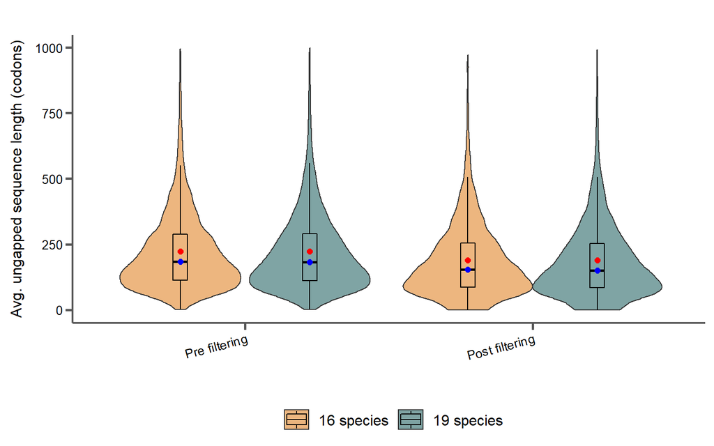

```r
pre_filt_len = select(aln_data, align, pre.avg.nongap.length, dataset)
names(pre_filt_len)[2] = "length"
pre_filt_len$label = "Pre filtering"

post_filt_len = select(aln_data, align, post.avg.nongap.length, dataset)
names(post_filt_len)[2] = "length"
post_filt_len$label = "Post filtering"

aln_lens = rbind(pre_filt_len, post_filt_len)

aln_means = aln_lens %>% group_by(dataset, label) %>% summarize(avg.length=mean(length, na.rm=T), median.length=median(length, na.rm=T), max.length=max(length, na.rm=T))

aln_lens$label = factor(aln_lens$label, levels=c("Pre filtering", "Post filtering"), ordered=T)
aln_lens$dataset = factor(aln_lens$dataset, levels=c("16 species", "19 species"), ordered=T)
aln_lens = subset(aln_lens, length < 1000)

aln_means$label = factor(aln_means$label, levels=c("Pre filtering", "Post filtering"), ordered=T)

dodge = position_dodge(width = 0.9)

aln_lens_p = ggplot(aln_lens, aes(x=label, y=length, fill=dataset)) +
  #geom_quasirandom(size=2, width=0.25, alpha=0.1, color="#666666") +
  geom_violin(alpha=0.5, position=dodge) +
  geom_boxplot(outlier.shape=NA, alpha=0, width=0.1, position=dodge, color="#000000") +
  geom_point(data=aln_means, aes(x=label, y=avg.length, group=dataset), size=2, color="red", position=dodge, show.legend=FALSE) +
  geom_point(data=aln_means, aes(x=label, y=median.length, group=dataset), size=2, color="blue", position=dodge, show.legend=FALSE) +
  ylab("Avg. ungapped sequence length (codons)") +
  xlab("") +
  scale_fill_manual(labels=c("16 species", "19 species"), values=corecol()) +
  bartheme() +
  theme(legend.position="bottom", axis.text.x = element_text(angle=15, hjust=1))
print(aln_lens_p)
```

```r
aln_means %>% kable() %>% kable_styling(bootstrap_options=c("striped", "condended", "responsive"), full_width=F)
```

| dataset | label | avg.length | median.length | max.length |
| --- | --- | --- | --- | --- |
| 16 species | Post filtering | 189.6262 | 153.1222 | 2996.500 |
| 16 species | Pre filtering | 223.2694 | 183.6410 | 3022.500 |
| 19 species | Post filtering | 188.5286 | 150.8167 | 2313.571 |
| 19 species | Pre filtering | 223.2874 | 182.5147 | 2387.071 |

# 6 Gappy sites per alignment

Sites where >20% of sequences contain gaps (—)

Recall, the codon window filter removes windows where 2 codons have 2 or more gaps in a 3 codon window in 50% or more of sequences.

Distributions visualized from subset of alignments with fewer than 1000 gappy sites.

- Red points denote average number of gappy sites considering the FULL distribution
- Blue points denote median number of gappy sites considering the FULL distribution
- Table shows summary statistics from FULL distribution

Pre = before codon window trimming and gappy sequence removal

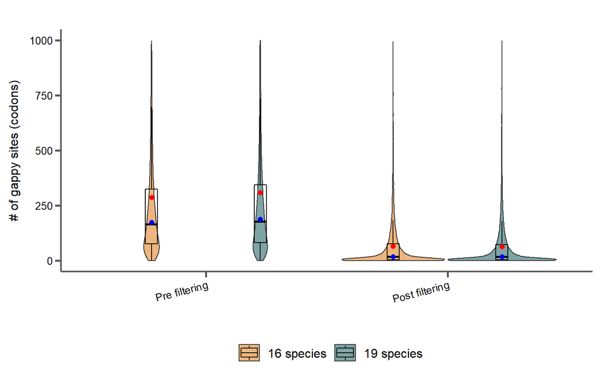

```r
pre_filt_sites = select(aln_data, align, pre.gappy.sites, dataset)
names(pre_filt_sites)[2] = "gappy.sites"
pre_filt_sites$label = "Pre filtering"

post_filt_sites = select(aln_data, align, post.gappy.sites, dataset)
names(post_filt_sites)[2] = "gappy.sites"
post_filt_sites$label = "Post filtering"

aln_gappy_sites = rbind(pre_filt_sites, post_filt_sites)

aln_gappy_means = aln_gappy_sites %>% group_by(dataset, label) %>% summarize(avg.gappy.sites=mean(gappy.sites, na.rm=T), median.gappy.sites=median(gappy.sites, na.rm=T), max.gappy.sites=max(gappy.sites, na.rm=T))

aln_gappy_sites$label = factor(aln_gappy_sites$label, levels=c("Pre filtering", "Post filtering"), ordered=T)
aln_gappy_sites$dataset = factor(aln_gappy_sites$dataset, levels=c("16 species", "19 species"), ordered=T)
aln_gappy_sites = subset(aln_gappy_sites, gappy.sites < 1000)

aln_gappy_means$label = factor(aln_gappy_means$label, levels=c("Pre filtering", "Post filtering"), ordered=T)

dodge = position_dodge(width = 0.9)

aln_gappy_p = ggplot(aln_gappy_sites, aes(x=label, y=gappy.sites, fill=dataset)) +
  #geom_quasirandom(size=2, width=0.25, alpha=0.1, color="#666666") +
  geom_violin(alpha=0.5, position=dodge) +
  geom_boxplot(outlier.shape=NA, alpha=0, width=0.1, position=dodge, color="#000000") +
  geom_point(data=aln_gappy_means, aes(x=label, y=avg.gappy.sites, group=dataset), size=2, color="red", position=dodge, show.legend=FALSE) +
  geom_point(data=aln_gappy_means, aes(x=label, y=median.gappy.sites, group=dataset), size=2, color="blue", position=dodge, show.legend=FALSE) +
  ylab("# of gappy sites (codons)") +
  xlab("") +
  scale_fill_manual(labels=c("16 species", "19 species"), values=corecol()) +
  bartheme() +
  theme(legend.position="bottom", axis.text.x = element_text(angle=15, hjust=1))
print(aln_gappy_p)
```

```r
aln_gappy_means %>% kable() %>% kable_styling(bootstrap_options=c("striped", "condended", "responsive"), full_width=F)
```

| dataset | label | avg.gappy.sites | median.gappy.sites | max.gappy.sites |
| --- | --- | --- | --- | --- |
| 16 species | Post filtering | 65.41299 | 17 | 1768 |
| 16 species | Pre filtering | 286.41266 | 173 | 3871 |
| 19 species | Post filtering | 64.08186 | 17 | 1999 |
| 19 species | Pre filtering | 307.26552 | 188 | 5708 |

# 7 Informative sites (NTs) per alignment

An alignment site is informative if it has at least 2 alleles present in at least 2 sequences.

Distributions visualized from subset of alignments with fewer than 1000 informative sites.

- Red points denote average number of informative sites considering the FULL distribution
- Blue points denote median number of informative sites considering the FULL distribution
- Table shows summary statistics from FULL distribution

Pre = before codon window trimming and gappy sequence removal

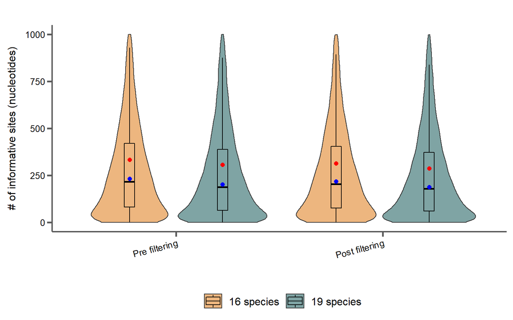

```r
pre_filt_sites = select(aln_data, align, pre.informative.nt.sites, dataset)
names(pre_filt_sites)[2] = "informative.sites"
pre_filt_sites$label = "Pre filtering"

post_filt_sites = select(aln_data, align, post.informative.nt.sites, dataset)
names(post_filt_sites)[2] = "informative.sites"
post_filt_sites$label = "Post filtering"

aln_informative_sites = rbind(pre_filt_sites, post_filt_sites)

aln_informative_means = aln_informative_sites %>% group_by(dataset, label) %>% summarize(avg.informative.sites=mean(informative.sites, na.rm=T), median.informative.sites=median(informative.sites, na.rm=T), max.informative.sites=max(informative.sites, na.rm=T))

aln_informative_sites$label = factor(aln_informative_sites$label, levels=c("Pre filtering", "Post filtering"), ordered=T)
aln_informative_sites$dataset = factor(aln_informative_sites$dataset, levels=c("16 species", "19 species"), ordered=T)
aln_informative_sites = subset(aln_informative_sites, informative.sites < 1000)

aln_informative_means$label = factor(aln_informative_means$label, levels=c("Pre filtering", "Post filtering"), ordered=T)

dodge = position_dodge(width = 0.9)

aln_informative_p = ggplot(aln_informative_sites, aes(x=label, y=informative.sites, fill=dataset)) +
  #geom_quasirandom(size=2, width=0.25, alpha=0.1, color="#666666") +
  geom_violin(alpha=0.5, position=dodge) +
  geom_boxplot(outlier.shape=NA, alpha=0, width=0.1, position=dodge, color="#000000") +
  geom_point(data=aln_informative_means, aes(x=label, y=avg.informative.sites, group=dataset), size=2, color="red", position=dodge, show.legend=FALSE) +
  geom_point(data=aln_informative_means, aes(x=label, y=median.informative.sites, group=dataset), size=2, color="blue", position=dodge, show.legend=FALSE) +
  ylab("# of informative sites (nucleotides)") +
  xlab("") +
  scale_fill_manual(labels=c("16 species", "19 species"), values=corecol()) +
  bartheme() +
  theme(legend.position="bottom", axis.text.x = element_text(angle=15, hjust=1))
print(aln_informative_p)
```

```r
aln_informative_means %>% kable() %>% kable_styling(bootstrap_options=c("striped", "condended", "responsive"), full_width=F)
```

| dataset | label | avg.informative.sites | median.informative.sites | max.informative.sites |
| --- | --- | --- | --- | --- |
| 16 species | Post filtering | 313.1389 | 218 | 4113 |
| 16 species | Pre filtering | 332.3709 | 231 | 4365 |
| 19 species | Post filtering | 286.1299 | 188 | 6459 |
| 19 species | Pre filtering | 305.4594 | 202 | 6607 |

Binning loci by # of informative sites. The largest bin both pre- and post-filter is informative sites = 0.

```r
bins_16 = seq(-1, max(aln_data_16$pre.informative.nt.sites, na.rm=T), by=1)
bin_labels_16 = seq(0, max(aln_data_16$pre.informative.nt.sites, na.rm=T), by=1)
pre_counts_16 = hist(aln_data_16$pre.informative.nt.sites, breaks=bins_16, include.lowest=T, plot=F)$counts
pre_binned_16 = data.frame("informative.sites"=bin_labels_16, "loci"=pre_counts_16)
pre_binned_16$dataset = "16 species"

bins_19 = seq(-1, max(aln_data_19$pre.informative.nt.sites, na.rm=T), by=1)
bin_labels_19 = seq(0, max(aln_data_19$pre.informative.nt.sites, na.rm=T), by=1)
pre_counts_19 = hist(aln_data_19$pre.informative.nt.sites, breaks=bins_19, include.lowest=T, plot=F)$counts
pre_binned_19 = data.frame("informative.sites"=bin_labels_19, "loci"=pre_counts_19)
pre_binned_19$dataset = "19 species"

pre_binned = merge(pre_binned_16, pre_binned_19, by="informative.sites")

head(pre_binned) %>% kable(caption="Pre-filter informative sites (NT)") %>% kable_styling(bootstrap_options=c("striped", "condended", "responsive"), full_width=F)
```

Pre-filter informative sites (NT)

| informative.sites | loci.x | dataset.x | loci.y | dataset.y |
| --- | --- | --- | --- | --- |
| 0 | 445 | 16 species | 545 | 19 species |
| 1 | 15 | 16 species | 44 | 19 species |
| 2 | 13 | 16 species | 31 | 19 species |
| 3 | 14 | 16 species | 36 | 19 species |
| 4 | 10 | 16 species | 38 | 19 species |
| 5 | 20 | 16 species | 44 | 19 species |

```r
bins_16 = seq(-1, max(aln_data_16$post.informative.nt.sites, na.rm=T), by=1)
bin_labels_16 = seq(0, max(aln_data_16$post.informative.nt.sites, na.rm=T), by=1)
post_counts_16 = hist(aln_data_16$post.informative.nt.sites, breaks=bins_16, include.lowest=T, plot=F)$counts
post_binned_16 = data.frame("informative.sites"=bin_labels_16, "loci"=post_counts_16)
post_binned_16$dataset = "16 species"

bins_19 = seq(-1, max(aln_data_19$post.informative.nt.sites, na.rm=T), by=1)
bin_labels_19 = seq(0, max(aln_data_19$post.informative.nt.sites, na.rm=T), by=1)
post_counts_19 = hist(aln_data_19$post.informative.nt.sites, breaks=bins_19, include.lowest=T, plot=F)$counts
post_binned_19 = data.frame("informative.sites"=bin_labels_19, "loci"=post_counts_19)
post_binned_19$dataset = "19 species"

post_binned = merge(post_binned_16, post_binned_19, by="informative.sites")

head(post_binned) %>% kable(caption="Post-filter informative sites (NT)") %>% kable_styling(bootstrap_options=c("striped", "condended", "responsive"), full_width=F)
```

Post-filter informative sites (NT)

| informative.sites | loci.x | dataset.x | loci.y | dataset.y |
| --- | --- | --- | --- | --- |
| 0 | 518 | 16 species | 658 | 19 species |
| 1 | 13 | 16 species | 32 | 19 species |
| 2 | 10 | 16 species | 31 | 19 species |
| 3 | 8 | 16 species | 36 | 19 species |
| 4 | 13 | 16 species | 37 | 19 species |
| 5 | 15 | 16 species | 44 | 19 species |

# 8 Informative sites (codons) per alignment

An alignment site is informative if it has at least 2 alleles present in at least 2 sequences.

Distributions visualized from subset of alignments with fewer than 1000 informative sites.

- Red points denote average number of informative sites considering the FULL distribution
- Blue points denote median number of informative sites considering the FULL distribution
- Table shows summary statistics from FULL distribution

Pre = before codon window trimming and gappy sequence removal

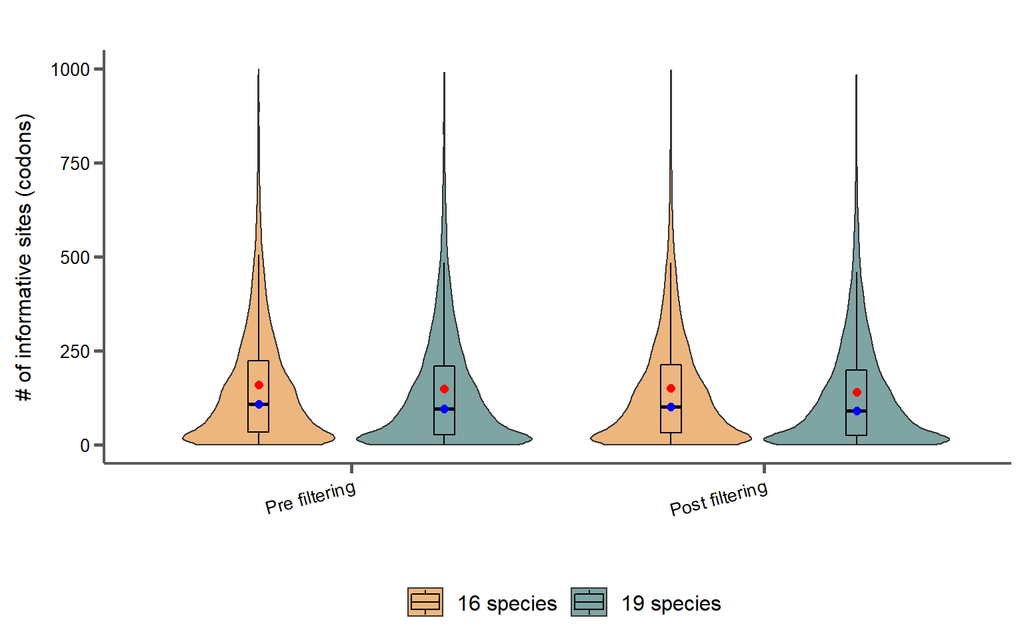

```r
pre_filt_sites = select(aln_data, align, pre.informative.codon.sites, dataset)
names(pre_filt_sites)[2] = "informative.sites"
pre_filt_sites$label = "Pre filtering"

post_filt_sites = select(aln_data, align, post.informative.codon.sites, dataset)
names(post_filt_sites)[2] = "informative.sites"
post_filt_sites$label = "Post filtering"

aln_informative_sites = rbind(pre_filt_sites, post_filt_sites)

aln_informative_means = aln_informative_sites %>% group_by(dataset, label) %>% summarize(avg.informative.sites=mean(informative.sites, na.rm=T), median.informative.sites=median(informative.sites, na.rm=T), max.informative.sites=max(informative.sites, na.rm=T))

aln_informative_sites$label = factor(aln_informative_sites$label, levels=c("Pre filtering", "Post filtering"), ordered=T)
aln_informative_sites$dataset = factor(aln_informative_sites$dataset, levels=c("16 species", "19 species"), ordered=T)
aln_informative_sites = subset(aln_informative_sites, informative.sites < 1000)

aln_informative_means$label = factor(aln_informative_means$label, levels=c("Pre filtering", "Post filtering"), ordered=T)

dodge = position_dodge(width = 0.9)

aln_informative_p = ggplot(aln_informative_sites, aes(x=label, y=informative.sites, fill=dataset)) +
  #geom_quasirandom(size=2, width=0.25, alpha=0.1, color="#666666") +
  geom_violin(alpha=0.5, position=dodge) +
  geom_boxplot(outlier.shape=NA, alpha=0, width=0.1, position=dodge, color="#000000") +
  geom_point(data=aln_informative_means, aes(x=label, y=avg.informative.sites, group=dataset), size=2, color="red", position=dodge, show.legend=FALSE) +
  geom_point(data=aln_informative_means, aes(x=label, y=median.informative.sites, group=dataset), size=2, color="blue", position=dodge, show.legend=FALSE) +
  ylab("# of informative sites (codons)") +
  xlab("") +
  scale_fill_manual(labels=c("16 species", "19 species"), values=corecol()) +
  bartheme() +
  theme(legend.position="bottom", axis.text.x = element_text(angle=15, hjust=1))
print(aln_informative_p)
```

```r
aln_informative_means %>% kable() %>% kable_styling(bootstrap_options=c("striped", "condended", "responsive"), full_width=F)
```

| dataset | label | avg.informative.sites | median.informative.sites | max.informative.sites |
| --- | --- | --- | --- | --- |
| 16 species | Post filtering | 150.2282 | 101 | 1739 |
| 16 species | Pre filtering | 158.5747 | 108 | 1841 |
| 19 species | Post filtering | 139.3044 | 89 | 2579 |
| 19 species | Pre filtering | 148.1334 | 95 | 2634 |

Binning loci by # of informative sites. The largest bin both pre- and post-filter is informative sites = 0.

```r
bins_16 = seq(-1, max(aln_data_16$pre.informative.codon.sites, na.rm=T), by=1)
bin_labels_16 = seq(0, max(aln_data_16$pre.informative.codon.sites, na.rm=T), by=1)
pre_counts_16 = hist(aln_data_16$pre.informative.codon.sites, breaks=bins_16, include.lowest=T, plot=F)$counts
pre_binned_16 = data.frame("informative.sites"=bin_labels_16, "loci"=pre_counts_16)
pre_binned_16$dataset = "16 species"

bins_19 = seq(-1, max(aln_data_19$pre.informative.codon.sites, na.rm=T), by=1)
bin_labels_19 = seq(0, max(aln_data_19$pre.informative.codon.sites, na.rm=T), by=1)
pre_counts_19 = hist(aln_data_19$pre.informative.codon.sites, breaks=bins_19, include.lowest=T, plot=F)$counts
pre_binned_19 = data.frame("informative.sites"=bin_labels_19, "loci"=pre_counts_19)
pre_binned_19$dataset = "19 species"

pre_binned = merge(pre_binned_16, pre_binned_19, by="informative.sites")

head(pre_binned) %>% kable(caption="Pre-filter informative sites (codons)") %>% kable_styling(bootstrap_options=c("striped", "condended", "responsive"), full_width=F)
```

Pre-filter informative sites (codons)

| informative.sites | loci.x | dataset.x | loci.y | dataset.y |
| --- | --- | --- | --- | --- |
| 0 | 467 | 16 species | 603 | 19 species |
| 1 | 70 | 16 species | 137 | 19 species |
| 2 | 66 | 16 species | 140 | 19 species |
| 3 | 98 | 16 species | 161 | 19 species |
| 4 | 102 | 16 species | 169 | 19 species |
| 5 | 129 | 16 species | 170 | 19 species |

```r
bins_16 = seq(-1, max(aln_data_16$post.informative.codon.sites, na.rm=T), by=1)
bin_labels_16 = seq(0, max(aln_data_16$post.informative.codon.sites, na.rm=T), by=1)
post_counts_16 = hist(aln_data_16$post.informative.codon.sites, breaks=bins_16, include.lowest=T, plot=F)$counts
post_binned_16 = data.frame("informative.sites"=bin_labels_16, "loci"=post_counts_16)
post_binned_16$dataset = "16 species"

bins_19 = seq(-1, max(aln_data_19$post.informative.codon.sites, na.rm=T), by=1)
bin_labels_19 = seq(0, max(aln_data_19$post.informative.codon.sites, na.rm=T), by=1)
post_counts_19 = hist(aln_data_19$post.informative.codon.sites, breaks=bins_19, include.lowest=T, plot=F)$counts
post_binned_19 = data.frame("informative.sites"=bin_labels_19, "loci"=post_counts_19)
post_binned_19$dataset = "19 species"

head(post_binned) %>% kable(caption="Post-filter informative sites (codons)") %>% kable_styling(bootstrap_options=c("striped", "condended", "responsive"), full_width=F)
```

Post-filter informative sites (codons)

[output not shown]

[output not shown]